# GH Slice Sampling

Jyotishka Datta

Tuesday, March 10, 2016

## Sampling from Gauss Hypergeometric Posterior

This document outlines possible strategies for sampling from the Gauss Hypergeometric distributionin the context of inference for a high dimensional sparse Poisson mean as decribed in the following paper:

[*Inference on High-Dimensional Sparse Count Data*](http://arxiv.org/abs/1510.04320): Datta, J and Dunson, D. (2016+)

### Exponential Slice Sampling

The first strategy is to use the exponential slice sampling for drawing samples from the Gauss Hypergeometric distribution for fixed values of the hyper-parameters $\gamma$ and $\tau^2$. As Datta and Dunson (2016) noted, the $\gamma$ paarmeter acts as a threshold to separate the low counts from the high counts that are true signals, and the $\tau^2$ acts as a global shrinkage parameter that adjusts to the overall sparsity in the data.

The Gauss-Hypergeometric prior is pseudo-conjugate in the sense that it produces a Gauss-Hypergeometric posterior when combined with a negative binomial likelihood. Recall that a negative binomial likelihood results when we put a Gamma prior on a Poisson rate parameter.

Our hierarchical model is: $Y_i \sim \mbox{NegBin}(\alpha, 1-\kappa_i) \equiv p(y_i | \kappa_i, \alpha) \propto (1-\kappa_i)^{y_i} \kappa_i^{\alpha} \\ p(\kappa_i | \tau^2, \gamma) \propto \kappa_i^{a-1} (1-\kappa_i)^{b-1} (1+\kappa_i (\tau^2-1))^{-\gamma}$

For modelling sparse count data, we recommend $a = b = \frac{1}{2}$, which results in the posterior: $p(\kappa_i | y_i, \gamma, \tau^2, \alpha) \propto \kappa_i^{\alpha-1/2} (1-\kappa_i)^{y_i - 1/2} (1+\kappa_i (\tau^2-1))^{-\gamma}$

We use the R package “truncdist” for drawing from a truncated distribution:

```r
if ("truncdist" %in% rownames(installed.packages()) == FALSE) {
    install.packages("truncdist", repos = "http://cran.us.r-project.org")
}
library(truncdist)
## sampling from gauss hypergeometric posterior for given tau-sq and gamma
rGaussHG <- function(r, y, gamma, t2, alpha) {
    p = length(y)
    k = rep(1/4, p)
    K = matrix(0, p, r)
    Omega = matrix(0, p, r)
    U = matrix(0, p, r)
    TH = matrix(0, p, r)

    for (i in 1:r) {
        omega = rgamma(p, shape = gamma, rate = k * (t2 - 1) + 1)
        u = runif(p, 0, exp(omega * k * (1 - t2)))
        s1 = rep(alpha + 1/2, p)
        s2 = y + 1/2
        if (t2 < 1) {
            lb = pmax(log(u)/(omega * (1 - t2)), 0)
            ub = rep(1, p)
        } else {
            ub = pmin(log(1/u)/(omega * (t2 - 1)), 1)
            lb = rep(0, p)
        }
        k = rtrunc(p, "beta", a = lb, b = ub, shape1 = s1, shape2 = s2)
        theta = rgamma(p, y + 1, 1/(1 - k))
        K[, i] = k
        Omega[, i] = omega
        U[, i] = u
        TH[, i] = theta
    }
    list(K = K, U = U, TH = TH)
}
```

We can also evaluate the posterior density since we know the normalizing constant and validate if the samples drawn using the sampling scheme above are indeed following the Gauss Hypergeometric distribution.

```r
library(BMS)
vf21hyper = Vectorize(f21hyper)
dGaussHG <- function(x,a,b,c,z){
C = beta(a,b)*vf21hyper(c,a,a+b,-z)
den = x^(a-1)*(1-x)^(b-1)*(1+z*x)^(-c)
return(den/C)
}
```

The function “rGaussHG” returns the samples drawn from the posterior and the function “dGaussHG” returns the density values for a chosen value or sequence of $\kappa_i$’s.

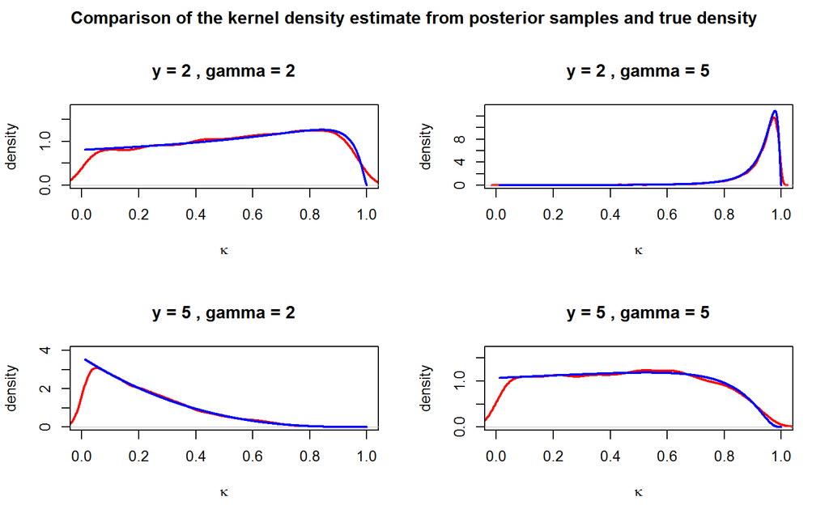

```r
kappa.vals = seq(0.01,1,length.out = 10000)
tau.sq = 0.05; a = 1/2; b = 1/2; z = tau.sq - 1
y.set = c(2,5); gamma.set = c(2,5)
par(oma=c(0,0,2,0))
par(mfrow=c(2,2))
for(i in 1:2){
  for (j in 1:2){
    y = y.set[i]; gamma = gamma.set[j]
    dpost <- dGaussHG(kappa.vals,a+1/2,y+b,gamma,z)
    ans = rGaussHG(10000,y,gamma,tau.sq,a)
    rpost <- ans$K
    ymax = max(dpost)
    d_rpost<- density(rpost)
    plot(d_rpost, col="red",lwd=2, ylim=c(0,ymax+0.5), xlim=c(0,1),
         xlab = expression(kappa) ,ylab = "density", main = paste("y =", y, ", gamma =", gamma, sep =" "))
    lines(kappa.vals,dpost,type="l",col="blue",lwd=2)
  }
}
title(main = "Comparison of the kernel density estimate from posterior samples and true density",outer=T)
```